# M0401241052_M0401241051_Tugas1Praktikum

- **Nur Annisa Hartanti Putri - M0401241051**
- **Rachel Anindya Aulia Safitri - M0401241052**

# Latihan Soal 1

```r
# Matriks kovarian
Sigma <- matrix(c(4, 1, 0,
                  1, 3, 0,
                  0, 0, 2),
                nrow = 3, byrow = TRUE)

Sigma
```

```
##      [,1] [,2] [,3]
## [1,]    4    1    0
## [2,]    1    3    0
## [3,]    0    0    2
```

## 1. Apakah X1 dan X3 saling bebas?

```r
cov_x1_x3 <- Sigma[1, 3]
cov_x1_x3
```

```
## [1] 0
```

```r
cov_x1_x3 == 0
```

```
## [1] TRUE
```

Nilai kovarian antara $X_1$ dan $X_3$ adalah 0. Hasil pengecekan juga menunjukkan `TRUE`, sehingga $X_1$ dan $X_3$ saling bebas.

## 2. Apakah (X1, X3) dan X2 saling bebas?

```r
# Mengubah urutan peubah menjadi X1, X3, X2
Sigma_star <- Sigma[c(1, 3, 2), c(1, 3, 2)]
Sigma_star
```

```
##      [,1] [,2] [,3]
## [1,]    4    0    1
## [2,]    0    2    0
## [3,]    1    0    3
```

```r
# Mengambil kovarian silang antara (X1, X3) dan X2
Sigma_star12 <- Sigma_star[1:2, 3, drop = FALSE]
Sigma_star12
```

```
##      [,1]
## [1,]    1
## [2,]    0
```

```r
# Mengecek apakah seluruh kovarian silang sama dengan 0
all(Sigma_star12 == 0)
```

```
## [1] FALSE
```

Matriks kovarian disusun kembali berdasarkan urutan $X_1, X_3, X_2$, sehingga diperoleh kovarian silang

$$\Sigma_{*12} =
\begin{bmatrix}
1\\
0
\end{bmatrix}.$$

Karena tidak seluruh elemen kovarian silang bernilai 0 dan hasil pengecekan menunjukkan `FALSE`, maka $(X_1, X_3)$ dan $X_2$ tidak saling bebas.

# Latihan Soal 2

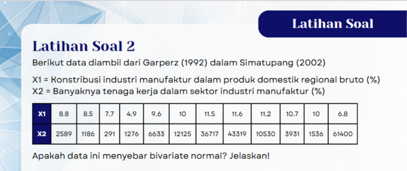

## Input Data

```r
# Memasukkan data
x <- c(8.8, 8.5, 7.7, 4.9, 9.6, 10, 11.5, 11.6, 11.2, 10.7, 10, 6.8,2589, 1186, 291, 1276, 6633, 12125, 36717, 43319, 10530, 3931, 1536, 61400)

# Membentuk matriks 12 baris dan 2 kolom
data <- matrix(x, nrow = 12, ncol = 2)

# Memberi nama kolom
colnames(data) <- c("X1", "X2")

data
```

```
##         X1    X2
##  [1,]  8.8  2589
##  [2,]  8.5  1186
##  [3,]  7.7   291
##  [4,]  4.9  1276
##  [5,]  9.6  6633
##  [6,] 10.0 12125
##  [7,] 11.5 36717
##  [8,] 11.6 43319
##  [9,] 11.2 10530
## [10,] 10.7  3931
## [11,] 10.0  1536
## [12,]  6.8 61400
```

## Uji Normalitas menggunakan Mardia’s Test

### Cara 1

```r
library(psych)
```

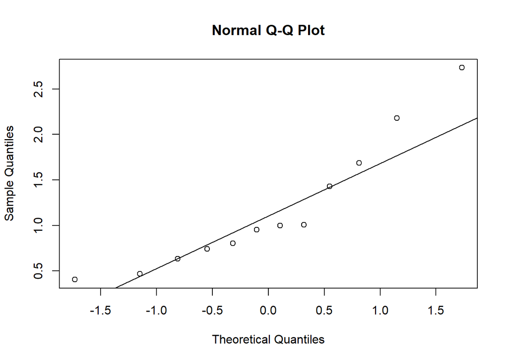

```r
# 1. Eksekusi Uji Mardia & Visualisasi Q-Q Plot
mardia <- psych::mardia(data, plot = TRUE)
```

```r
# 2. Matriks Kovarians
cov(data)
```

```
##             X1           X2
## X1    4.165682 5.471739e+03
## X2 5471.738636 4.161796e+08
```

```r
# 3. Cetak Hasil Pengujian Hipotesis
cat("           PENGUJIAN HIPOTESIS MARDIA            \n")
```

```
##            PENGUJIAN HIPOTESIS MARDIA
```

```r
cat("H0 : Data menyebar mengikuti distribusi normal multivariat\n")
```

```
## H0 : Data menyebar mengikuti distribusi normal multivariat
```

```r
cat("H1 : Data TIDAK menyebar mengikuti distribusi normal multivariat\n")
```

```
## H1 : Data TIDAK menyebar mengikuti distribusi normal multivariat
```

```r
cat("1. Uji Skewness (Kemiringan):\n")
```

```
## 1. Uji Skewness (Kemiringan):
```

```r
cat("   - p-value   :", round(mardia$p.skew, 4), "\n")
```

```
##    - p-value   : 0.2147
```

```r
cat("   - Keputusan :", ifelse(mardia$p.skew > 0.05, "Terima H0 (Normal)", "Tolak H0 (Tidak Normal)"), "\n\n")
```

```
##    - Keputusan : Terima H0 (Normal)
```

```r
cat("2. Uji Kurtosis (Keruncingan):\n")
```

```
## 2. Uji Kurtosis (Keruncingan):
```

```r
cat("   - p-value   :", round(mardia$p.kurt, 4), "\n")
```

```
##    - p-value   : 0.9541
```

```r
cat("   - Keputusan :", ifelse(mardia$p.kurt > 0.05, "Terima H0 (Normal)", "Tolak H0 (Tidak Normal)"), "\n")
```

```
##    - Keputusan : Terima H0 (Normal)
```

### Cara 2

```r
library(MVN)
```

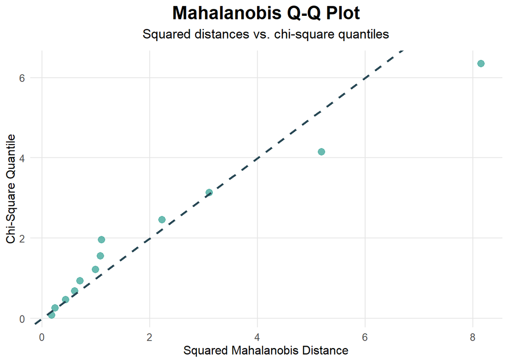

```r
mardia <- mvn(data, mvn_test = c("mardia"))
plot(mardia, diagnostic = "multivariate", type = "qq")
```

```r
mardia
```

```
## $multivariate_normality
##              Test Statistic p.value     Method          MVN
## 1 Mardia Skewness    11.122   0.025 asymptotic ✗ Not normal
## 2 Mardia Kurtosis     0.590   0.555 asymptotic     ✓ Normal
##
## $univariate_normality
##               Test Variable Statistic p.value    Normality
## 1 Anderson-Darling       X1     0.312   0.505     ✓ Normal
## 2 Anderson-Darling       X2     1.382  <0.001 ✗ Not normal
##
## $descriptives
##   Variable  n      Mean   Std.Dev Median   Min     Max   25th      75th  Skew
## 1       X1 12     9.275     2.041    9.8   4.9    11.6    8.3    10.825 -0.77
## 2       X2 12 15127.750 20400.481 5282.0 291.0 61400.0 1471.0 18273.000  1.30
##   Kurtosis
## 1    2.758
## 2    3.227
##
## $data
##         X1    X2
##  [1,]  8.8  2589
##  [2,]  8.5  1186
##  [3,]  7.7   291
##  [4,]  4.9  1276
##  [5,]  9.6  6633
##  [6,] 10.0 12125
##  [7,] 11.5 36717
##  [8,] 11.6 43319
##  [9,] 11.2 10530
## [10,] 10.7  3931
## [11,] 10.0  1536
## [12,]  6.8 61400
##
## $subset
## NULL
##
## $outlierMethod
## [1] "none"
##
## attr(,"class")
## [1] "mvn"
```

### Kesimpulan

Dari hasil R diatas akan dilakukan pengujian hipotesis terhadap mardia skewness test sebagai berikut :

- H0 : Peubah ganda mengikuti distribusi normal
- H1 : Peubah ganda tidak mengikuti distribusi normal

Berdasarkan hasil uji Mardia menggunakan package `psych`, diperoleh p-value pada uji skewness sebesar 0.2147 dan uji kurtosis sebesar 0.9541. Kedua p-value tersebut lebih besar dari α = 0.05, sehingga H₀ tidak ditolak. Dengan demikian, berdasarkan uji Mardia menggunakan cara 1, data X1 dan X2 dapat dianggap mengikuti distribusi normal multivariat.  
Berdasarkan hasil uji Mardia menggunakan package `MVN`, diperoleh p-value pada uji skewness sebesar 0.025 < 0.05, sehingga H₀ ditolak. Sementara itu, uji kurtosis menghasilkan p-value sebesar 0.555 > 0.05, sehingga H₀ tidak ditolak. Dengan demikian, berdasarkan uji Mardia menggunakan cara 2, terdapat indikasi bahwa data X1 dan X2 tidak mengikuti distribusi normal multivariat karena uji skewness menunjukkan hasil yang signifikan.  
Hasil pengujian menggunakan dua metode menunjukkan hasil yang berbeda. Pada cara 1 menggunakan `psych::mardia()`, baik skewness maupun kurtosis tidak signifikan sehingga data dianggap normal multivariat. Sementara itu, pada cara 2 menggunakan `MVN::mvn()`, uji skewness signifikan sedangkan kurtosis tidak signifikan, sehingga terdapat indikasi ketidaknormalan multivariat.

## Uji normalitas ganda menggunakan Henze-Zikler Test

### Cara 1

```r
library(mvnTest)
# 1. Eksekusi Uji Henze-Zirkler
hz_result <- HZ.test(data)

# 2. Tampilkan Output Ringkas
print(hz_result)
```

```
##             Henze-Zirkler test for Multivariate Normality
##
##   data : data
##
##   HZ              : 0.9692663
##   p-value         : 0.005110511
##
##   Result  : Data are not multivariate normal (sig.level = 0.05)
```

### Cara 2

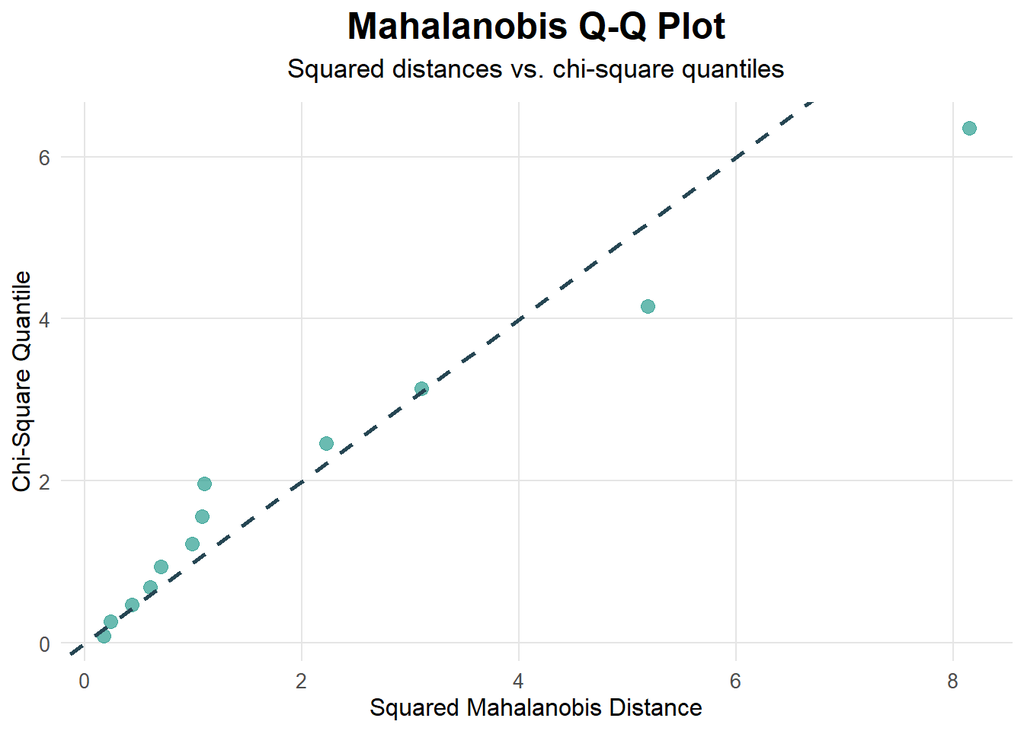

```r
henze <- mvn(data, mvn_test = c("hz"))
plot(henze, diagnostic = "multivariate", type = "qq")
```

```r
henze
```

```
## $multivariate_normality
##            Test Statistic p.value     Method          MVN
## 1 Henze-Zirkler         1   0.004 asymptotic ✗ Not normal
##
## $univariate_normality
##               Test Variable Statistic p.value    Normality
## 1 Anderson-Darling       X1     0.312   0.505     ✓ Normal
## 2 Anderson-Darling       X2     1.382  <0.001 ✗ Not normal
##
## $descriptives
##   Variable  n      Mean   Std.Dev Median   Min     Max   25th      75th  Skew
## 1       X1 12     9.275     2.041    9.8   4.9    11.6    8.3    10.825 -0.77
## 2       X2 12 15127.750 20400.481 5282.0 291.0 61400.0 1471.0 18273.000  1.30
##   Kurtosis
## 1    2.758
## 2    3.227
##
## $data
##         X1    X2
##  [1,]  8.8  2589
##  [2,]  8.5  1186
##  [3,]  7.7   291
##  [4,]  4.9  1276
##  [5,]  9.6  6633
##  [6,] 10.0 12125
##  [7,] 11.5 36717
##  [8,] 11.6 43319
##  [9,] 11.2 10530
## [10,] 10.7  3931
## [11,] 10.0  1536
## [12,]  6.8 61400
##
## $subset
## NULL
##
## $outlierMethod
## [1] "none"
##
## attr(,"class")
## [1] "mvn"
```

### Kesimpulan

Berdasarkan hasil uji Henze-Zirkler menggunakan cara 1, diperoleh p-value sebesar 0.0051. Nilai tersebut lebih kecil dari α = 0.05, sehingga H₀ ditolak. Dengan demikian, berdasarkan uji Henze-Zirkler menggunakan cara 1, data X1 dan X2 tidak mengikuti distribusi normal multivariat.

Berdasarkan hasil uji Henze-Zirkler menggunakan package `MVN`, diperoleh p-value sebesar 0.004. Nilai tersebut lebih kecil dari α = 0.05, sehingga H₀ ditolak. Dengan demikian, berdasarkan uji Henze-Zirkler menggunakan cara 2, data X1 dan X2 tidak mengikuti distribusi normal multivariat.

Hasil pengujian menggunakan dua cara menunjukkan kesimpulan yang sama. Pada cara 1 diperoleh p-value sebesar 0.0051, sedangkan pada cara 2 diperoleh p-value sebesar 0.004. Kedua p-value tersebut lebih kecil dari α = 0.05 sehingga H₀ ditolak. **Dengan demikian, berdasarkan uji Henze-Zirkler, data X1 dan X2 tidak mengikuti distribusi normal multivariat.** Hasil tersebut didukung oleh Mahalanobis Q-Q Plot, di mana sebagian besar titik pengamatan berada di sekitar garis diagonal, tetapi terdapat beberapa penyimpangan terutama pada bagian ekor kanan.

## Uji Normalitas ganda menggunakan Royston

```r
royston <- mvn(data, mvn_test = c("royston"))
plot(royston, diagnostic = "multivariate", type = "persp")
```

[interactive chart not shown]

```r
royston
```

```
## $multivariate_normality
##      Test Statistic p.value     Method          MVN
## 1 Royston    10.101   0.006 asymptotic ✗ Not normal
##
## $univariate_normality
##               Test Variable Statistic p.value    Normality
## 1 Anderson-Darling       X1     0.312   0.505     ✓ Normal
## 2 Anderson-Darling       X2     1.382  <0.001 ✗ Not normal
##
## $descriptives
##   Variable  n      Mean   Std.Dev Median   Min     Max   25th      75th  Skew
## 1       X1 12     9.275     2.041    9.8   4.9    11.6    8.3    10.825 -0.77
## 2       X2 12 15127.750 20400.481 5282.0 291.0 61400.0 1471.0 18273.000  1.30
##   Kurtosis
## 1    2.758
## 2    3.227
##
## $data
##         X1    X2
##  [1,]  8.8  2589
##  [2,]  8.5  1186
##  [3,]  7.7   291
##  [4,]  4.9  1276
##  [5,]  9.6  6633
##  [6,] 10.0 12125
##  [7,] 11.5 36717
##  [8,] 11.6 43319
##  [9,] 11.2 10530
## [10,] 10.7  3931
## [11,] 10.0  1536
## [12,]  6.8 61400
##
## $subset
## NULL
##
## $outlierMethod
## [1] "none"
##
## attr(,"class")
## [1] "mvn"
```

Dari Royston Test diperoleh nilai p-value sebesar 0,006. Dengan taraf signifikansi α=0,05, diperoleh 0,006< 0,05, sehingga H₀ ditolak. Dengan demikian, dapat disimpulkan bahwa peubah-peubah tersebut tidak mengikuti distribusi normal ganda (bivariat).

```r
royston1 <- mvn(data, mvn_test = c("royston"))
plot(royston, diagnostic = "multivariate", type = "contour")
```

[interactive chart not shown]

```r
royston1
```

```
## $multivariate_normality
##      Test Statistic p.value     Method          MVN
## 1 Royston    10.101   0.006 asymptotic ✗ Not normal
##
## $univariate_normality
##               Test Variable Statistic p.value    Normality
## 1 Anderson-Darling       X1     0.312   0.505     ✓ Normal
## 2 Anderson-Darling       X2     1.382  <0.001 ✗ Not normal
##
## $descriptives
##   Variable  n      Mean   Std.Dev Median   Min     Max   25th      75th  Skew
## 1       X1 12     9.275     2.041    9.8   4.9    11.6    8.3    10.825 -0.77
## 2       X2 12 15127.750 20400.481 5282.0 291.0 61400.0 1471.0 18273.000  1.30
##   Kurtosis
## 1    2.758
## 2    3.227
##
## $data
##         X1    X2
##  [1,]  8.8  2589
##  [2,]  8.5  1186
##  [3,]  7.7   291
##  [4,]  4.9  1276
##  [5,]  9.6  6633
##  [6,] 10.0 12125
##  [7,] 11.5 36717
##  [8,] 11.6 43319
##  [9,] 11.2 10530
## [10,] 10.7  3931
## [11,] 10.0  1536
## [12,]  6.8 61400
##
## $subset
## NULL
##
## $outlierMethod
## [1] "none"
##
## attr(,"class")
## [1] "mvn"
```

## Kesimpulan

Berdasarkan seluruh pengujian normalitas multivariat yang telah dilakukan, yaitu **Mardia Test, Henze-Zirkler Test, dan Royston Test**, diperoleh hasil yang menunjukkan adanya perbedaan pada beberapa pengujian Mardia. Pada `psych::mardia()`, uji skewness dan kurtosis menghasilkan p-value masing-masing sebesar **0,2147** dan **0,9541**, sehingga H₀ tidak ditolak. Sementara itu, pada `MVN::mvn()`, uji Mardia Skewness menghasilkan **p-value 0,025 < 0,05**, sehingga H₀ ditolak, sedangkan Mardia Kurtosis menghasilkan **p-value 0,555 > 0,05**, sehingga H₀ tidak ditolak.

Namun, pada **uji Henze-Zirkler**, baik cara 1 maupun cara 2 memberikan hasil yang konsisten, dengan p-value masing-masing sebesar **0,0051** dan **0,004**, yang keduanya lebih kecil dari 0,05 sehingga H₀ ditolak. Hasil tersebut juga sejalan dengan **Royston Test** yang menghasilkan p-value sebesar **0,006 < 0,05**, sehingga H₀ ditolak. Selain itu, Mahalanobis Q-Q Plot menunjukkan adanya beberapa penyimpangan dari garis diagonal, terutama pada bagian ekor kanan.

**Dengan demikian, berdasarkan keseluruhan hasil pengujian, data X1 dan X2 dapat disimpulkan tidak mengikuti distribusi normal ganda (bivariat). Sehingga dapat dilakukan penangan lanjutan terhadap data tersebut, dapat menggunakan transformasi normal atau metode lainnya.**